# Mid-term Project – Aiding Africa

## **Plan 2: Minimum cost route to meet Aid requirements of each African cities**

```
## [1] "Objective Value = 310861.299435028"
```

```
##                       NY           JSV         Niger     D.R.Congo
## solution    5.000000e+05  5.000000e+05  1.000000e+05  1.800000e+05
## duals/coef -5.000000e-02  0.000000e+00  4.700000e-01  4.000000e-01
## Sens From   5.000000e+05 -1.000000e+30  0.000000e+00  7.000000e+04
## Sens Till   6.100000e+05  1.000000e+30  1.000000e+05  1.800000e+05
##                     Chad        Zambia         Gabon         Kenya
## solution    8.000000e+04  1.500000e+05  1.000000e+05  1.200000e+05
## duals/coef  4.200000e-01  3.800000e-01  1.700000e-01  4.100000e-01
## Sens From   3.000000e+04  4.000000e+04 -1.000000e+04 -5.000000e+04
## Sens Till   8.000000e+04  1.500000e+05  1.000000e+05  1.200000e+05
##                    Sudan        Angola       Senegal        uNY_Za
## solution    9.000000e+04  1.300000e+05  5.000000e+04  2.666667e+02
## duals/coef  3.300000e-01  1.700000e-01  1.800000e-01  0.000000e+00
## Sens From  -1.300000e+05  2.000000e+04  0.000000e+00 -1.000000e+30
## Sens Till   9.000000e+04  1.300000e+05  5.000000e+04  1.000000e+30
##                   uNY_Ga        uNY_Ke        uNY_Su        uNY_An
## solution    1.166667e+03  0.000000e+00  0.000000e+00  5.416667e+02
## duals/coef  0.000000e+00  0.000000e+00  0.000000e+00  0.000000e+00
## Sens From  -1.000000e+30 -1.000000e+30 -1.000000e+30 -1.000000e+30
## Sens Till   1.000000e+30  1.000000e+30  1.000000e+30  1.000000e+30
##                   uNY_Se       uJSV_Za       uJSV_Ga       uJSV_Ke
## solution    2.083333e+02  7.333333e+02  0.000000e+00  1.133333e+03
## duals/coef  0.000000e+00  0.000000e+00  0.000000e+00  0.000000e+00
## Sens From  -1.000000e+30 -1.000000e+30 -1.000000e+30 -1.000000e+30
## Sens Till   1.000000e+30  1.000000e+30  1.000000e+30  1.000000e+30
##                  uJSV_Su       uJSV_An       uJSV_Se        uZa_Ni
## solution    1.466667e+03  0.000000e+00  0.000000e+00  0.000000e+00
## duals/coef  0.000000e+00  0.000000e+00  0.000000e+00  0.000000e+00
## Sens From  -1.000000e+30 -1.000000e+30 -1.000000e+30 -1.000000e+30
## Sens Till   1.000000e+30  1.000000e+30  1.000000e+30  1.000000e+30
##                   uGa_Ni        uKe_Ni        uSu_Ni        uAn_Ni
## solution    0.000000e+00  0.000000e+00  6.666667e+02  0.000000e+00
## duals/coef -2.340000e+00  0.000000e+00  0.000000e+00 -2.340000e+00
## Sens From   0.000000e+00 -1.000000e+30 -1.000000e+30  0.000000e+00
## Sens Till   2.259890e+03  1.000000e+30  1.000000e+30  2.259890e+03
##                   uSe_Ni        uZa_Co        uGa_Co        uKe_Co
## solution    0.000000e+00  0.000000e+00  1.016949e+04  0.000000e+00
## duals/coef -1.900000e-01  0.000000e+00  0.000000e+00  0.000000e+00
## Sens From   0.000000e+00 -1.000000e+30 -1.000000e+30 -1.000000e+30
## Sens Till   2.259890e+03  1.000000e+30  1.000000e+30  1.000000e+30
```

[output cut: 35 more lines]

```
##                    Ga_Co         Ke_Co         Su_Co         An_Co
## solution    1.016949e+04  0.000000e+00  0.000000e+00  0.000000e+00
## duals/coef  4.000000e+00  2.500000e+01  1.900000e+01  5.000000e+00
## Sens From  -3.040000e+00 -1.350000e+00  1.065000e+01  4.000000e+00
## Sens Till   4.990000e+00  1.000000e+30  1.000000e+30  1.000000e+30
##                    Se_Co         Za_Ch         Ga_Ch         Ke_Ch
## solution    0.000000e+00  0.000000e+00  0.000000e+00  3.333333e+02
## duals/coef  5.000000e+00  2.300000e+01  7.000000e+00  2.000000e+00
## Sens From   3.850000e+00  6.000000e+00  4.400000e+00 -8.000000e+00
## Sens Till   1.000000e+30  1.000000e+30  1.000000e+30  1.900000e+01
##                    Su_Ch         An_Ch         Se_Ch
## solution    2.000000e+02  0.000000e+00  0.000000e+00
## duals/coef  4.000000e+00  8.000000e+00  9.000000e+00
## Sens From  -1.000000e+30  4.400000e+00  4.250000e+00
## Sens Till   1.400000e+01  1.000000e+30  1.000000e+30
```

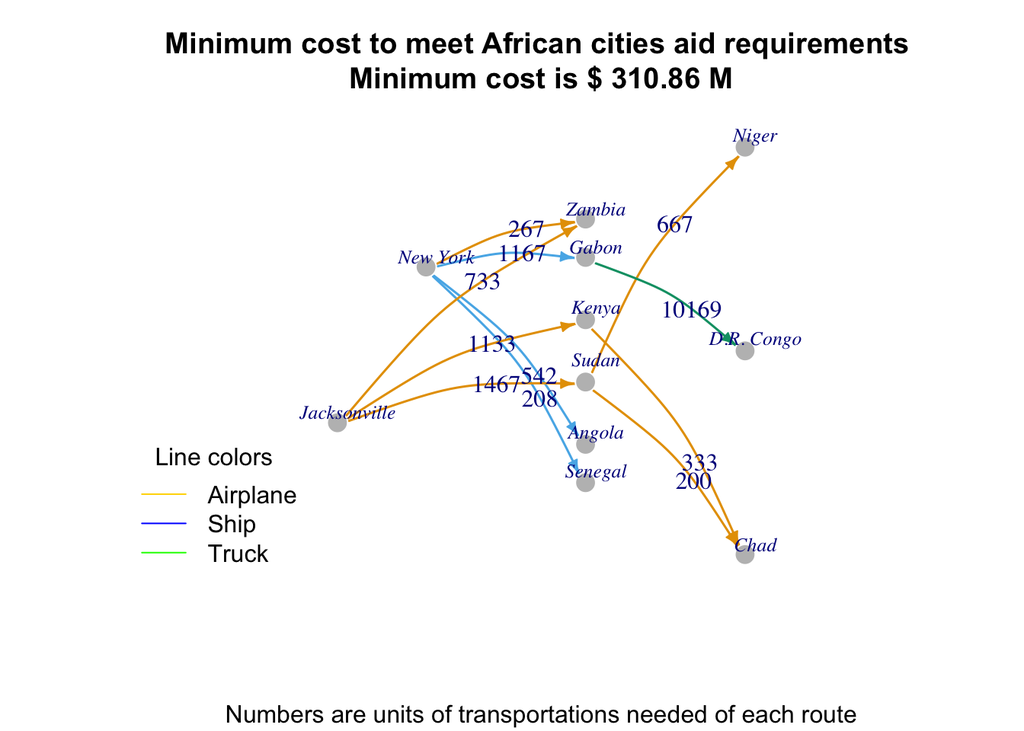

**Finding 2**

In this scenario, Sudan to Chad is the significant bottlenecks in the system as the dual value of the route capacity from Sudan to Chad is **-10**, which is the lowest among all routes. That is to say, increasing the capacity in this route by one unit will decrease the cost by **$10** through redesign of the routes. This cost reduction is effective unless the capacity of this route reaches **533**.This is the largest cost reduce IFRC can have through increasing one unit of capacity.

Another way to think about this is how to reduce cost within this allocation strategy. Among all the routes that’s chosen in our minimum cost plan with a positive lower sensitivity bound, we can see that the route from Jacksonville to Kenya has the highest value of *(Cost-lower sensitivity bound) x transportation units* of **$11330**, meaning that the biggest reduction on cost IFRC can have is **$11330** by reducing the cost of the route JSV-KE from **$61** to **$51**, without changing the route design.